# Independence Test for F and R Primers

Burcu

June 22, 2016

## Summary of the Dataset and Purpose

We would like to identify whether there is an interaction between forward and reverse primers and if there is an interaction, which particular forward and reverse primers are interacted. For independece analysis, we will use chi-square pearson residuals. We have 20 samples. Each sample has 260 different spike counts for each 20 forward (V) and 13 reverse (J) primer combinations (20x13=260). For creating these 20 samples, only spikes and primers were used in the PCR (no gemomic DNA were present).

E for a cell = row total x column total / grand total.

O is the observed count in a cell

Chi-squared statistic is calculated by summing over the 260 cells [(O-E)^2/E].

Pearson residual for each cell is calculated by (O-E)/sqrt(E)

## Aggregate all samples into a single table

Each sample has an individual file containing the 260 counts. We combine them into a single data frame prior to the analysis.

```r
# Set directory
count.dir <- "C:/Users/burcu/Desktop/TCR/knitr-git/norm_knitr/independence/160609_spike_counts_25bp/160609_only_spikes"

# Read in files and sort by sample number
all.counts <- list.files(count.dir)
all.counts <- all.counts[order(as.numeric(gsub(".*_S|.assembled.*", '', all.counts)))]

# Read in first file to start aggregate data frame
count.df <- read.table(file.path(count.dir, all.counts[1]), sep =',', header = T)
count.df <- count.df[,3:5]

# Combine spike counts for all files into 1 data frame
  # Columns are samples
  # Rows are spikes
for (i in 2:length(all.counts)){
  curr.df <- read.table(file.path(count.dir, all.counts[i]), sep = ',', header = T)
  count.df <- cbind(count.df, curr.df$spike.count)
}   #   for i in 2:length(new.counts)
colnames(count.df) <- c("V", "J", seq(1:length(all.counts)))
```

## Creating animation of heatmaps of pearson residual matrices of 20 samples to visualize the patterns

```r
# Creating a facet of heat maps with all samples next to each other by using ggplot

pear.res<-function(colName)
{
  temp.chi <- chisq.test(acast(count.df, V~J,value.var = colName) , correct = F)
  temp.res<- melt(temp.chi$residuals,id_vars=c("V","J"))
  temp.res$sample<-rep(colName,nrow(temp.res))
  temp.res
}

res<-lapply(colnames(count.df[ ,3:22]), pear.res)
res.bound<-do.call(rbind,res)
#res.bound<-merge(tissue.lookup, res.bound, by.x = "num", by.y="sample")

gg<-ggplot(res.bound, aes(x=Var1, y=Var2, fill=value, frame=sample))
gg<-gg+geom_tile(color="white", size=0.1)
gg<-gg+scale_fill_gradient2()+coord_equal()
gg<-gg+theme(axis.text=element_text(size=6))
gg<-gg+theme(axis.text.x = element_text(angle = 90))
#gg<-gg+facet_wrap(~sample, ncol=5)
gg_animate(gg)
```

```r
gg
```

[video not shown]

## Comments:

The actual spike counts vary a lot across samples (for instance, the spike count corresponding to a specific primer combination in one sample can be three to four times of another sample’s corresponding spike count) (Why? There is no genomic DNA and no low spike counts (I couldn’t see any lower than 50). Is this variation due to PCR?). Ratios of spike counts and their interactions however seem to vary much less (hence the preserved heatmap pattern accross samples). This points out to accross sample variation, but not within sample relatively. This is a good thing for normalization I guess.

To get a feeling about the scale of the data consider the spike counts for J2-2, J2-4, V15 and V16. For sample 1 they are: V15+J2-2:5434, V15+J2-4:657, V16+J2-2:99, V16+J2-4:4093. Comparing the first two values you’d think that J2-2 is far more efficient than J2-4 under no interaction assumption (10 fold) but it is completely reversed for V16 (40 fold less efficient). These ratios are preserved, rather remarkably accross all samples. This is one of the more dramatic 4-tuples but this is definitely not an exception.

These findings contradict the claim in the adaptive paper. They employed primer iteration based on no interaction assumption. However, based on this preliminary analysis, adjusting primer concentrations, as-is, rather tricky and perhaps unapplicable. For example, just trying to equilibrate for these 4 primers mentioned above will likely not work no matter the concentration combination we choose.

I guess taking this interaction pattern as a priori for the Bayesian normalization process might be an option- but the smoothing hoped to be gained from the 33 parameter model might be lost. If opted for retaining the smoothing, this much interaction might suggest reselecting primers or spikes. (I am more inclined to say spikes because the interactions seem not to be associated with a certain primer)

Note: I have seen the same pattern when I applied the code for heat map to previous data (with genomic DNA and higher level of primer concentration – so primer dimerization might not have been an issue)

## chi square test and residual table for one sample

```r
## Preperaing the chi square matrix (V as columns, J as rows)

vbyj.first<- acast(count.df, V~J, value.var = 14)

## Chi squared test

chi.first <- chisq.test(vbyj.first, correct = F)

## Creating residuals tables

resid.table.first <- chi.first$residuals
```

## Creating clustered and unclustered heatmaps for one sample

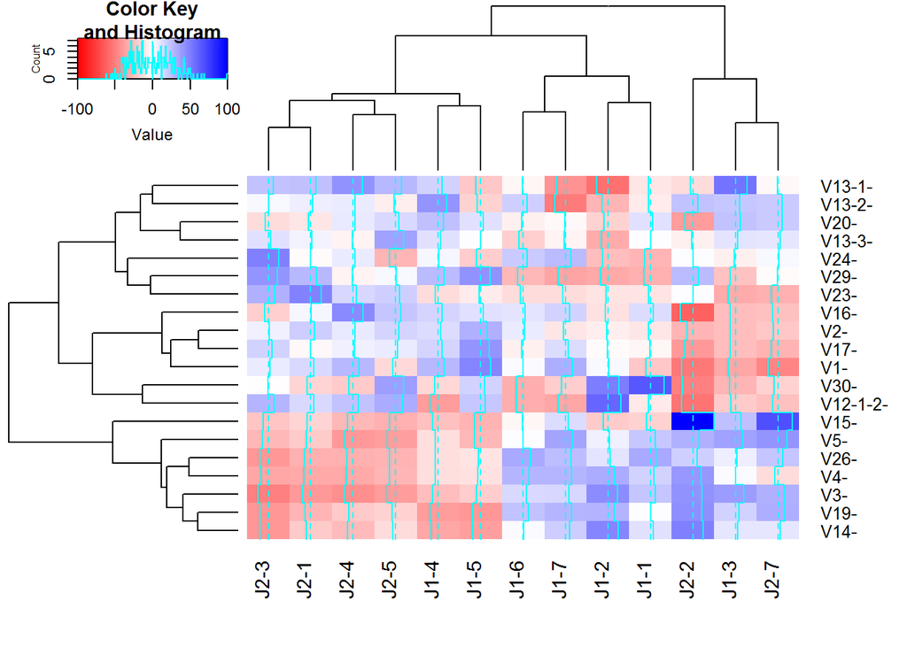

```r
bk = seq(-100, 100)
mycols<-colorRampPalette(colors = c("red", "white","blue"))(length(bk)-1)


# creating clustered heatmap without scaling

heatmap.2(resid.table.first, col=mycols, breaks=bk, scale='none')
```

## Comments:

I took one sample (as it shows the same pattern for each sample) and created clustered heatmap. In this clustered heatmap the variation of spike counts in both directions (positive or negative deviation from independence) is more visible. Increasing concentrations of one group of primers due to lower spike counts (red cells in one part of the heatmap) can adversely affect the purpose of reducing the amplification bias because there are also higher spike counts (blue cells) present for the same group of primers. There seems to be a cluster structure but I don’t know what to make of it.